## Clasifición de las variables

### MSSubClass

Identifica el tipo de vivienda involucrada en la venta.

Variable categórica nominal

### MSZoning

Identifica la clasificación general de la zona de venta

Variable categórica nominal

### LotFrontage

Cantidad de pies de la propiedad conectados a la calle

Variable cuantitativa continua

### LotArea

Tamaño del lote en pies cuadrados

Variable cuantitativa continua

### Street

Tipo del camino de acceso a la propiedad

Variable categórica nominal

### Alley

Tipo del callejón de acceso a la propiedad

Variable categórica nominal

### LotShape

Forma general de la propiedad

Variable categórica nominal

### LandContour

Horizontalidad de la propiedad

Variable categórica ordinal

### Utilities

Tipo de utilidades disponibles

Variable categórica nominal

### LotConfig

Configuración del lote

Variable categórica nominal

### LandSlope

Pendiente de la propiedad

Variable categórica ordinal

### Neighborhood

Ubicación dentro de la ciudad de Ames

Variable categórica nominal

### Condition1

Proximidad a condiciones varias

Variable categórica nominal

### Condition2

Proximidad a condiciones varias (si existe más de una presente)

Variable categórica nominal

### BldgType

Tipo de vivienda

Variable categórica nominal

### HouseStyle

Estilo de vivienda

Variable categórica nominal

### OverallQual

Calificación promedio de los materiales y acabados de la casa

Variable categórica ordinal

### OverallCond

Calificación promedio de la condición de la casa

Variable categórica ordinal

### YearBuilt

Fecha original de construcción

Variable categórica ordinal

### YearRemodAdd

Fecha de remodelación (misma que en construcción en caso no se hayan efectuado adiciones o remodelaciones)

Variable categórica ordinal

### RoofStyle

Tipo de techo

Variable categórica nominal

### RoofMatl

Material del techo

Variable categórica nominal

### Exterior1st

Revestimiento de la casa

Variable categórica nominal

### Exterior2nd

Revestimiento de la casa (en caso exista más de uno)

Variable categórica nominal

### MasVnrType

Tipo de mampostería

Variable categórica nominal

### MasVnrArea

Área de mampostería en pies cuadrados

Variable cuantitativa continua

### ExterQual

Evaluación de la calidad de los materiales del exterior

Variable categórica ordinal

### ExterCond

Evaluación de la condición presente de los materiales del exterior

Variable categórica ordinal

### Foundation

Tipo de cimentación

Variable categórica nominal

### BsmtQual

Evaluación de la altura del sótano

Variable categórica ordinal

### BsmtCond

Evaluación general de la condición del sótano

Variable categórica ordinal

### BsmtExposure

Evaluación de la pared perimetral

Variable categórica ordinal

### BsmtFinType1

Rating of basement finished area

Variable categórica ordinal

### BsmtFinSF1

Acabados de tipo 1 en pies cuadrados

Variable cuantitativa continua

### BsmtFinType2

Calificación de los acabados del sotano (si existe varios)

Variable categórica ordinal

### BsmtFinSF2

Acabados de tipo 2 en pies cuadrados

Variable cuantitativa continua

### BsmtUnfSF

Pies cuadrados sin terminar en el área del sótano

Variable cuantitativa continua

### TotalBsmtSF

Cantidad total de pies cuadrados en el área del sótano

Variable cuantitativa continua

### Heating

Tipo de calefacción

Variable categórica nominal

### HeatingQC

Calidad y condición de la calefacción

Variable categórica ordinal

### CentralAir

Aire acondicionado central

Variable categórica nominal

### Electrical

Sistema eléctrico

Variable categórica nominal

### 1stFlrSF

Pies cuadrados del primer piso

Variable cuantitativa continua

### 2ndFlrSF

Pies cuadrados del segundo piso

Variable cuantitativa continua

### LowQualFinSF

Cantidad de pies cuadrados con acabados de baja calidad

Variable cuantitativa continua

### GrLivArea

Cantidad de pies cuadrados de vivienda sobre la superficie

Variable cuantitativa continua

### BsmtFullBath

Cantidad de baños completos en el sótano

Variable cuantitativa discreta

### BsmtHalfBath

Cantidad de medios baños en el sótano

Variable cuantitativa discreta

### FullBath

Cantidad de baños completos sobre la superficie

Variable cuantitativa discreta

### HalfBath

Cantidad de medios baños sobre la superficie

Variable cuantitativa discreta

### Bedroom

Cantidad de dormitorios sobre la superficie (no incluye dormitorios en el sótano)

Variable cuantitativa discreta

### Kitchen

Cantidad de cocinas sobre la superficie

Variable cuantitativa discreta

### KitchenQual

Calidad de la cocina

Variable categórica ordinal

### TotRmsAbvGrd

Cantidad de cuartos sobre la superficie (no incluye baños)

Variable cuantitativa discreta

### Functional

Funcionalidad de casas (Se asumen típicas a menos qué la deducción este justificado)

Variable categórica nominal

### Fireplaces

Cantidad de chimeneas

Variable cuantitativa discreta

### FireplaceQu

Calidad de la chimenea

Variable categórica ordinal

### GarageType

Locación del garaje

Variable categórica nominal

### GarageYrBlt

Año en que se construyó el garaje

Variable categórica ordinal

### GarageFinish

Acabados interiores del garaje

Variable categórica ordinal

### GarageCars

Tamaño del garaje en capacidad de carros

Variable cuantitativa discreta

### GarageArea

Tamaño del garaje en pies cuadrados

Variable cuantitativa continua

### GarageQual

Calidad del garaje

Variable categórica ordinal

### GarageCond

Condiciones del garaje

Variable categórica ordinal

### PavedDrive

Pavimento de la entrada

Variable categórica nominal

### WoodDeckSF

Área del deck de madera en pies cuadrados

Variable cuantitativa continua

### OpenPorchSF

Área abierta del porche en pies cuadrados

Variable cuantitativa continua

### EnclosedPorch

Área cerrada del porche en pies cuadrados

Variable cuantitativa continua

### 3SsnPorch

Área de 3 temporadas del porche en pies cuadrados

Variable cuantitativa continua

### ScreenPorch

Área de pantalla del porche en pies cuadrados

Variable cuantitativa continua

### PoolArea

Área de piscina en pies cuadrados

Variable cuantitativa continua

### PoolQC

Calidad de la piscina

Variable categórica ordinal

### Fence

Calidad de la cerca

Variable categórica ordinal

### MiscFeature

Otras características no cubiertas en otra categoría

Variable categórica nominal

### MiscVal

Valor de las otras características

Variable categórica nominal

### MoSold

Mes en que se vendio

Variable categórica ordinal

### YrSold

Año en que se vendio

Variable categórica ordinal

### SaleType

Tipo de venta

Variable categórica nominal

### SaleCondition

Condiciones de venta

Variable categórica nominal

# Análisis de variables cuantitativas

### Análisis de correlación

Se seleccionanan las variables que son númericas. Asignanado 0 en los lugares en donde se encontra un Na.

```r
library(dplyr)
datosNumericos <- select(dataSet, LotArea,MasVnrArea,BsmtFinSF1,BsmtFinSF2,BsmtUnfSF,TotalBsmtSF,X1stFlrSF,X2ndFlrSF,LowQualFinSF,GrLivArea,BsmtFullBath,BsmtHalfBath,FullBath,HalfBath,TotRmsAbvGrd,Fireplaces,GarageCars,GarageArea,WoodDeckSF,OpenPorchSF,EnclosedPorch,X3SsnPorch,ScreenPorch,PoolArea)
datosNumericos[is.na(datosNumericos)] <- 0
datosNumericos2 <- datosNumericos
View(datosNumericos2)
```

```r
datosNumericos$LotArea <- as.numeric(datosNumericos$LotArea)
datosNumericos$MasVnrArea <- as.numeric(datosNumericos$MasVnrArea)
datosNumericos$BsmtFinSF1 <- as.numeric(datosNumericos$BsmtFinSF1)
datosNumericos$BsmtFinSF2 <- as.numeric(datosNumericos$BsmtFinSF2)
datosNumericos$BsmtUnfSF <- as.numeric(datosNumericos$BsmtUnfSF)
datosNumericos$TotalBsmtSF <- as.numeric(datosNumericos$TotalBsmtSF)
datosNumericos$X1stFlrSF <- as.numeric(datosNumericos$X1stFlrSF)
datosNumericos$X2ndFlrSF <- as.numeric(datosNumericos$X2ndFlrSF)
datosNumericos$LowQualFinSF <- as.numeric(datosNumericos$LowQualFinSF)
datosNumericos$GrLivArea <- as.numeric(datosNumericos$GrLivArea)
datosNumericos$BsmtFullBath <- as.numeric(datosNumericos$BsmtFullBath)
datosNumericos$BsmtHalfBath <- as.numeric(datosNumericos$BsmtHalfBath)
datosNumericos$FullBath <- as.numeric(datosNumericos$FullBath)
datosNumericos$HalfBath <- as.numeric(datosNumericos$HalfBath)
datosNumericos$TotRmsAbvGrd <- as.numeric(datosNumericos$TotRmsAbvGrd)
datosNumericos$Fireplaces <- as.numeric(datosNumericos$Fireplaces)
datosNumericos$GarageCars <- as.numeric(datosNumericos$GarageCars)
datosNumericos$GarageArea <- as.numeric(datosNumericos$GarageArea)
datosNumericos$WoodDeckSF <- as.numeric(datosNumericos$WoodDeckSF)
datosNumericos$OpenPorchSF <- as.numeric(datosNumericos$OpenPorchSF)
datosNumericos$EnclosedPorch <- as.numeric(datosNumericos$EnclosedPorch)
datosNumericos$X3SsnPorch <- as.numeric(datosNumericos$X3SsnPorch)
datosNumericos$ScreenPorch <- as.numeric(datosNumericos$ScreenPorch)
datosNumericos$PoolArea <- as.numeric(datosNumericos$PoolArea)
View(datosNumericos)
```

```r
correlacion <- cor(datosNumericos)
```

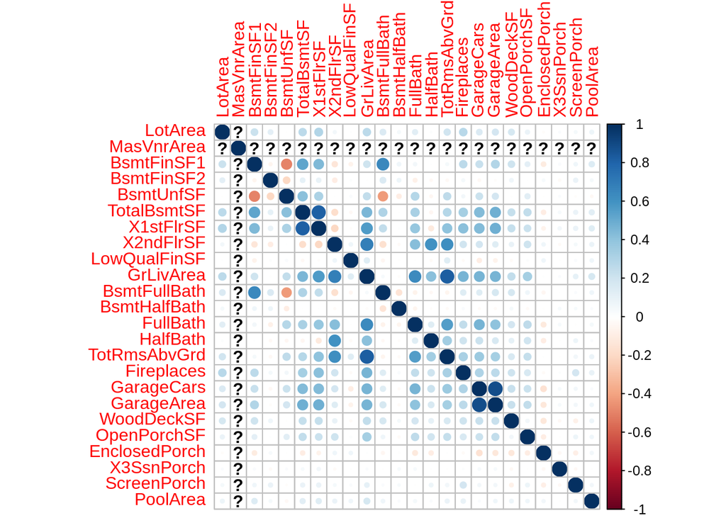

```r
library(corrplot)
corrplot(correlacion)
```

### Análisis de normalidad

A continuación, se realizan gráficas Q-Q (quantile-quantile) para conocer que tan normales son nuestras variables de tipo cuantitativo. Lo ideal es que los puntos se acerquen a una recta diagonal.

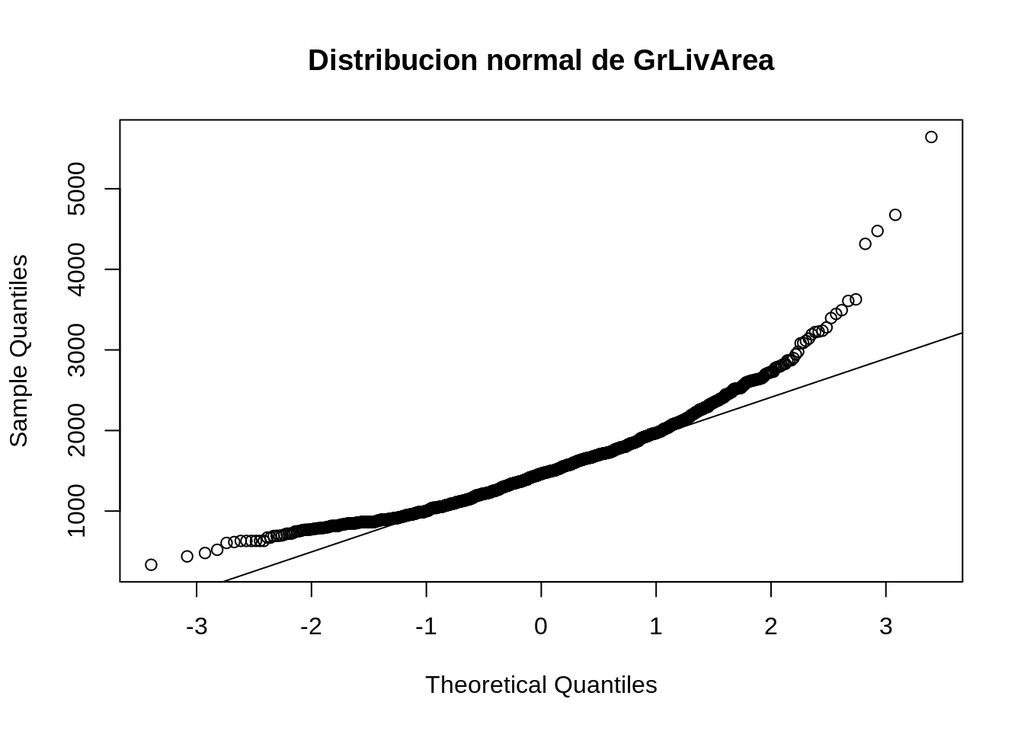

```r
qqnorm(na.omit(as.numeric(dataSet$GrLivArea)),main = "Distribucion normal de GrLivArea")
qqline(na.omit(as.numeric(dataSet$GrLivArea)))
```

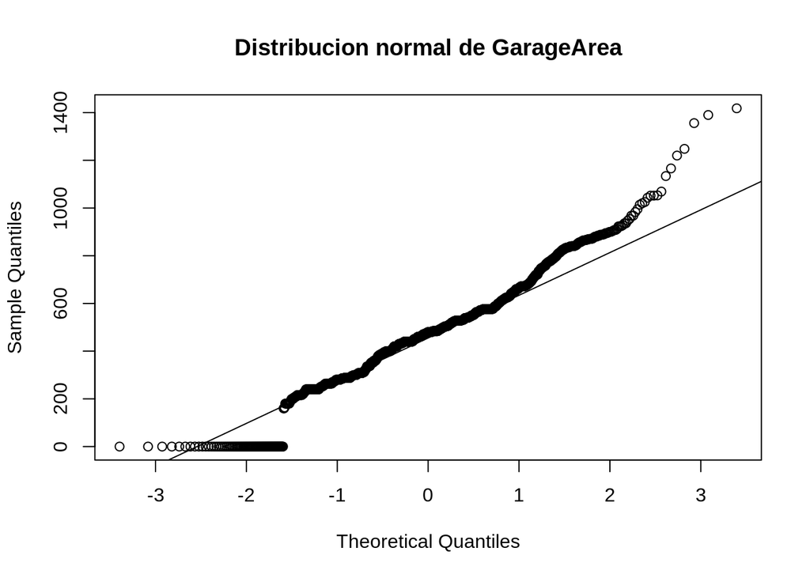

```r
qqnorm(na.omit(as.numeric(dataSet$GarageArea)),main = "Distribucion normal de GarageArea")
qqline(na.omit(as.numeric(dataSet$GarageArea)))
```

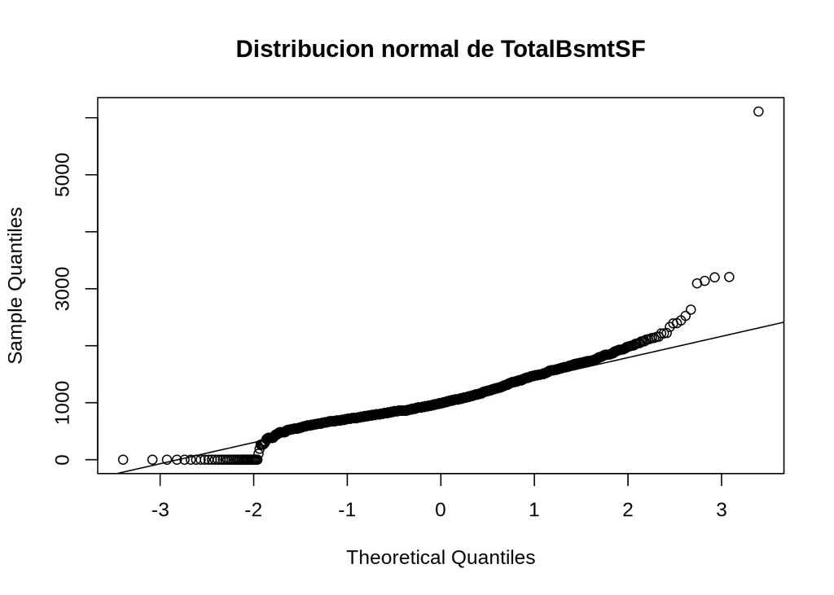

```r
qqnorm(na.omit(as.numeric(dataSet$TotalBsmtSF)),main = "Distribucion normal de TotalBsmtSF")
qqline(na.omit(as.numeric(dataSet$TotalBsmtSF)))
```

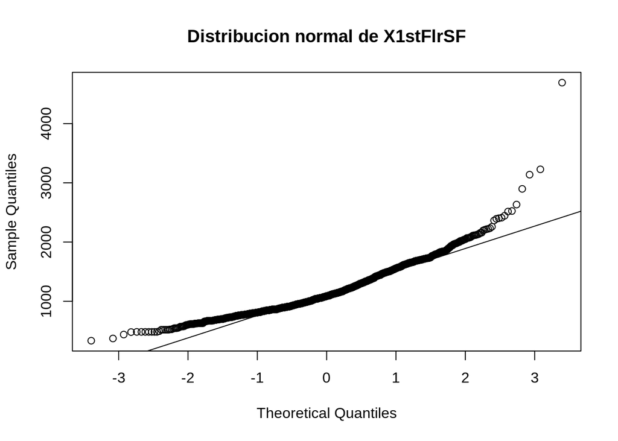

```r
qqnorm(na.omit(as.numeric(dataSet$X1stFlrSF)),main = "Distribucion normal de X1stFlrSF")
qqline(na.omit(as.numeric(dataSet$X1stFlrSF)))
```

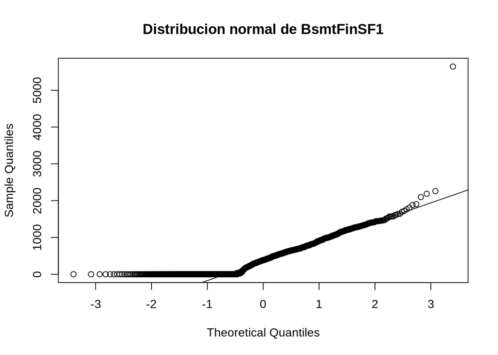

```r
qqnorm(na.omit(as.numeric(dataSet$BsmtFinSF1)),main = "Distribucion normal de BsmtFinSF1")
qqline(na.omit(as.numeric(dataSet$BsmtFinSF1)))
```

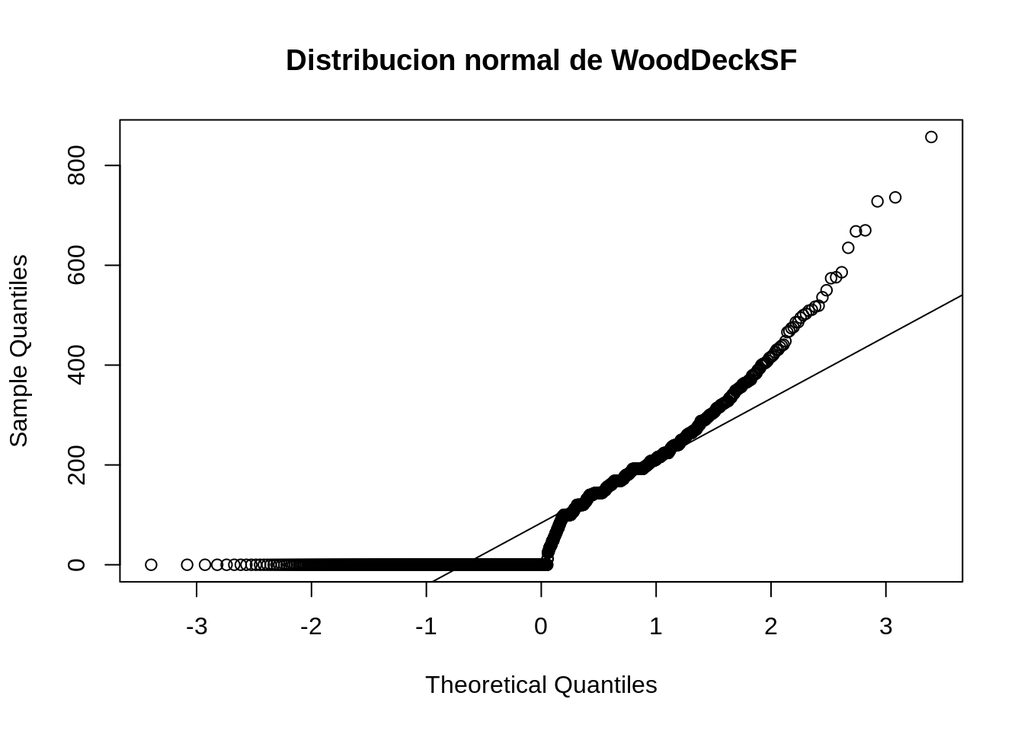

```r
qqnorm(na.omit(as.numeric(dataSet$WoodDeckSF)),main = "Distribucion normal de WoodDeckSF")
qqline(na.omit(as.numeric(dataSet$WoodDeckSF)))
```

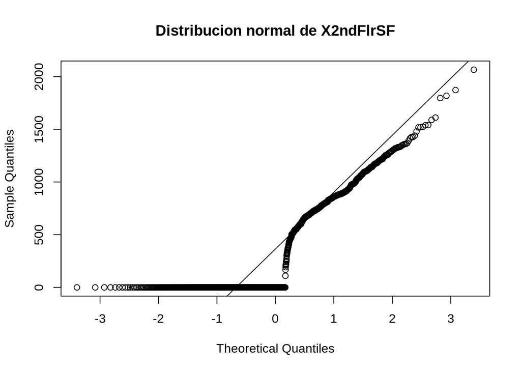

```r
qqnorm(na.omit(as.numeric(dataSet$X2ndFlrSF)),main = "Distribucion normal de X2ndFlrSF")
qqline(na.omit(as.numeric(dataSet$X2ndFlrSF)))
```

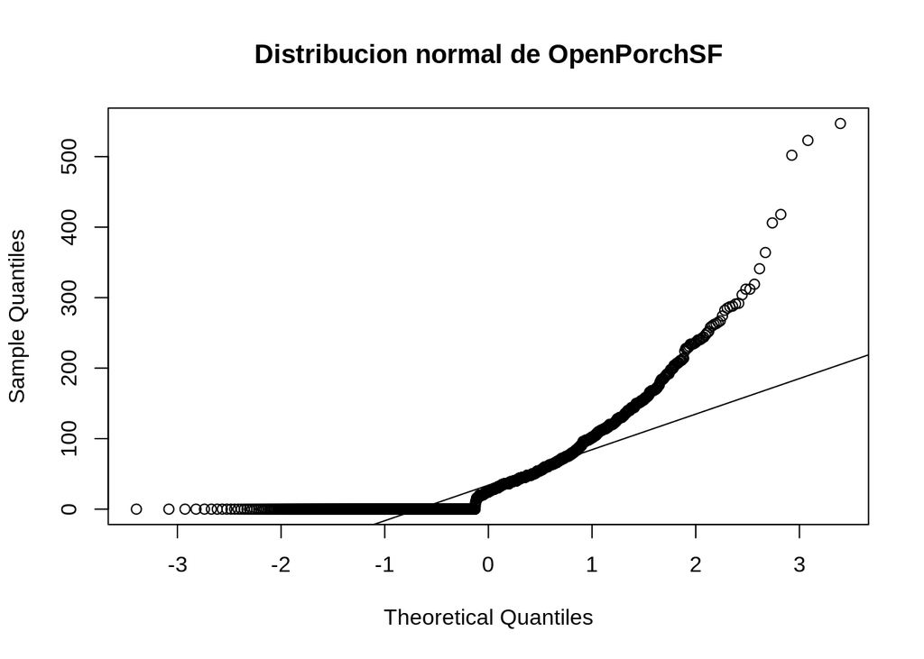

```r
qqnorm(na.omit(as.numeric(dataSet$OpenPorchSF)),main = "Distribucion normal de OpenPorchSF")
qqline(na.omit(as.numeric(dataSet$OpenPorchSF)))
```

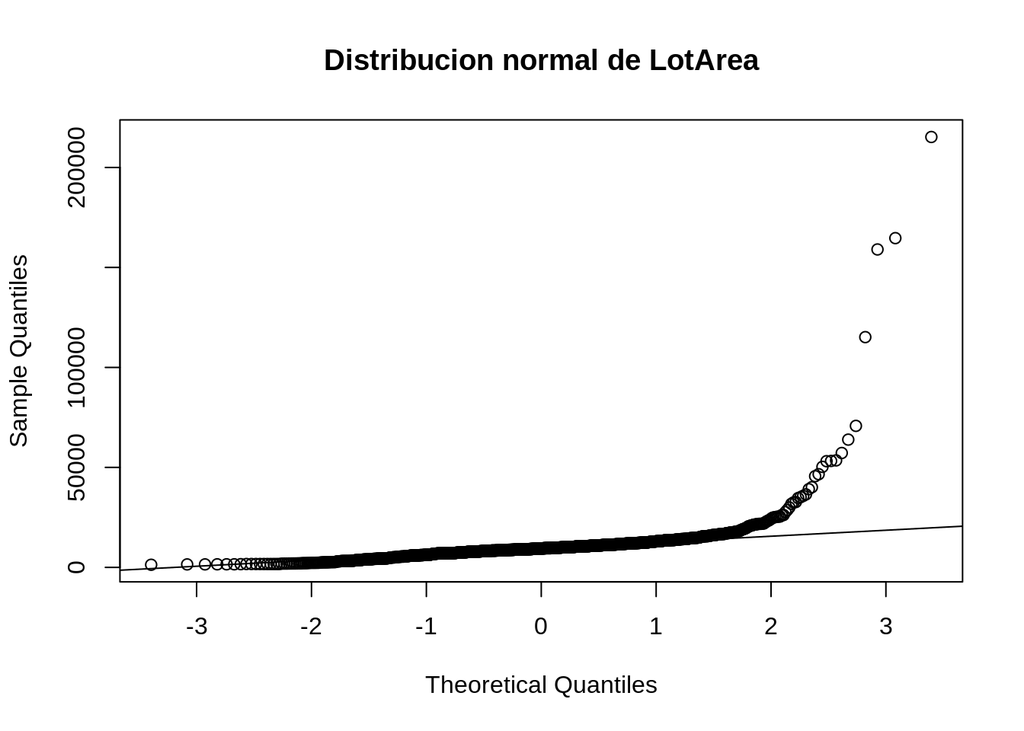

```r
qqnorm(na.omit(as.numeric(dataSet$LotArea)),main = "Distribucion normal de LotArea")
qqline(na.omit(as.numeric(dataSet$LotArea)))
```

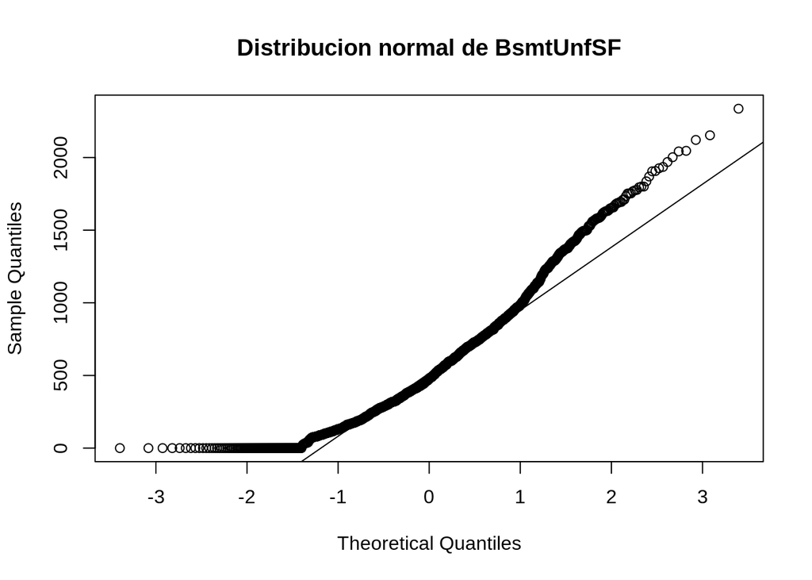

```r
qqnorm(na.omit(as.numeric(dataSet$BsmtUnfSF)),main = "Distribucion normal de BsmtUnfSF")
qqline(na.omit(as.numeric(dataSet$BsmtUnfSF)))
```

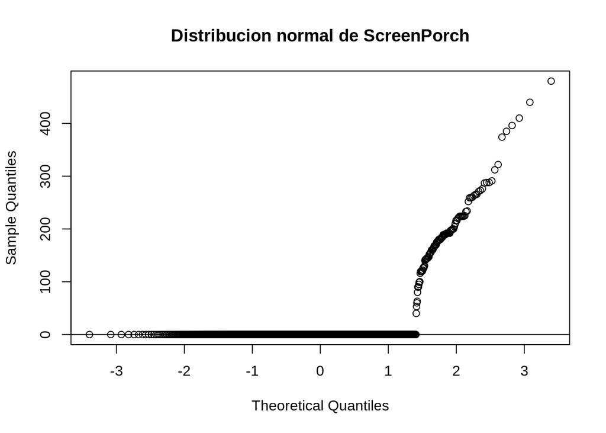

```r
qqnorm(na.omit(as.numeric(dataSet$ScreenPorch)),main = "Distribucion normal de ScreenPorch")
qqline(na.omit(as.numeric(dataSet$ScreenPorch)))
```

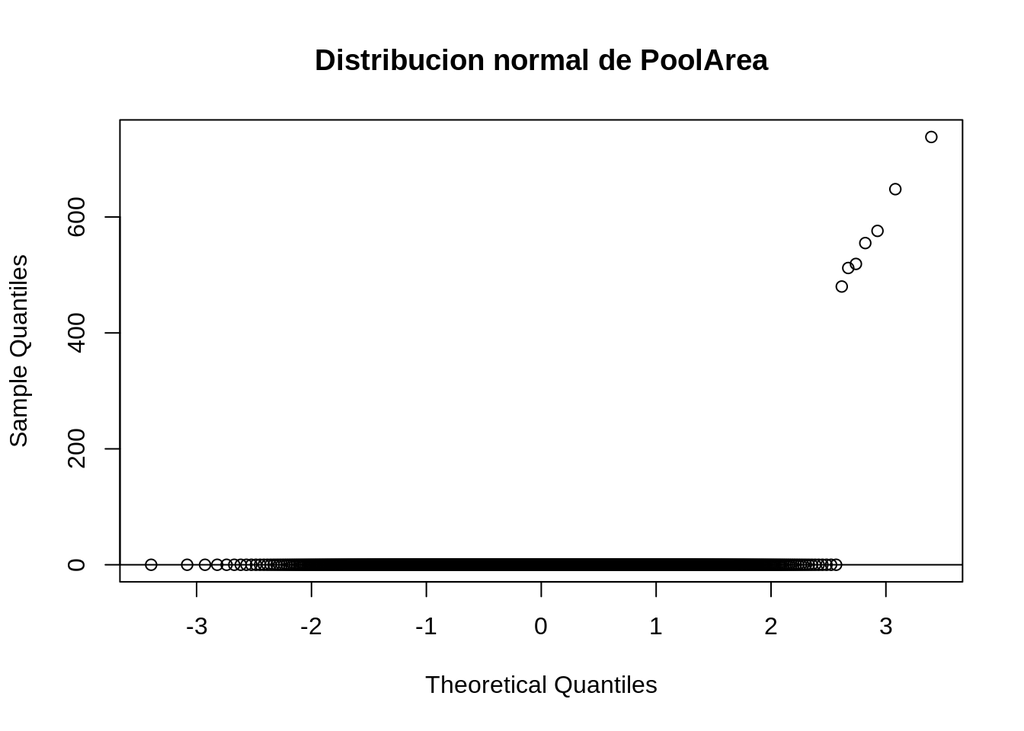

```r
qqnorm(na.omit(as.numeric(dataSet$PoolArea)),main = "Distribucion normal de PoolArea")
qqline(na.omit(as.numeric(dataSet$PoolArea)))
```

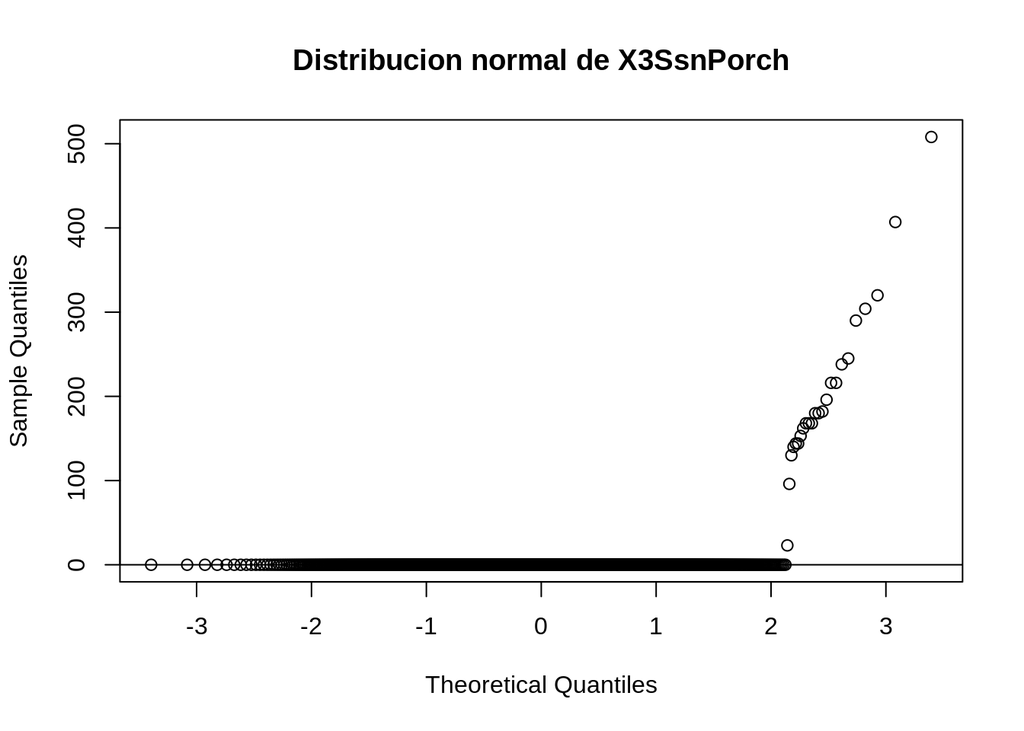

```r
qqnorm(na.omit(as.numeric(dataSet$X3SsnPorch)),main = "Distribucion normal de X3SsnPorch")
qqline(na.omit(as.numeric(dataSet$X3SsnPorch)))
```

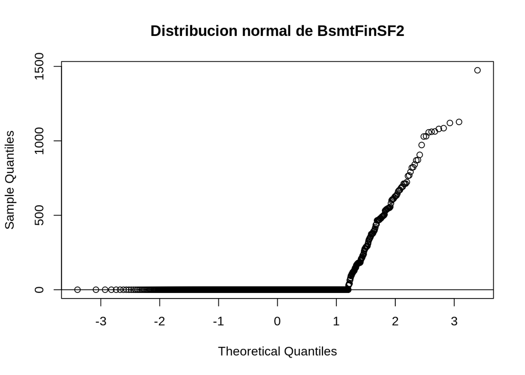

```r
qqnorm(na.omit(as.numeric(dataSet$BsmtFinSF2)),main = "Distribucion normal de BsmtFinSF2")
qqline(na.omit(as.numeric(dataSet$BsmtFinSF2)))
```

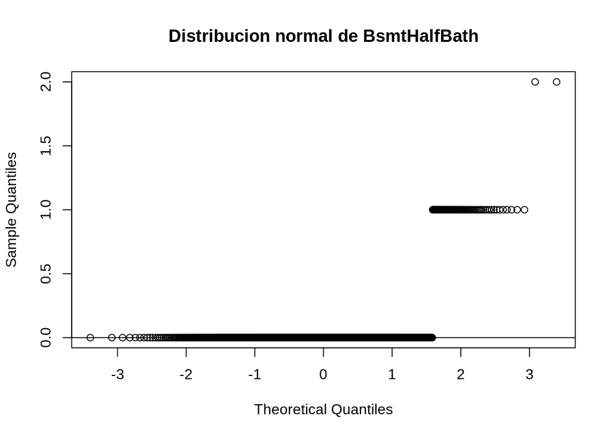

```r
qqnorm(na.omit(as.numeric(dataSet$BsmtHalfBath)),main = "Distribucion normal de BsmtHalfBath")
qqline(na.omit(as.numeric(dataSet$BsmtHalfBath)))
```

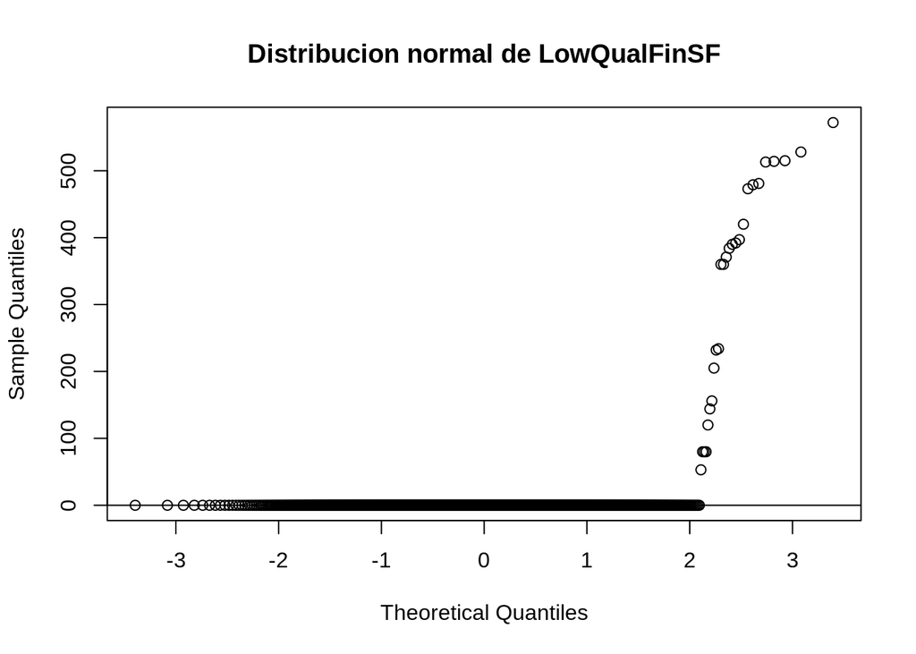

```r
qqnorm(na.omit(as.numeric(dataSet$LowQualFinSF)),main = "Distribucion normal de LowQualFinSF")
qqline(na.omit(as.numeric(dataSet$LowQualFinSF)))
```

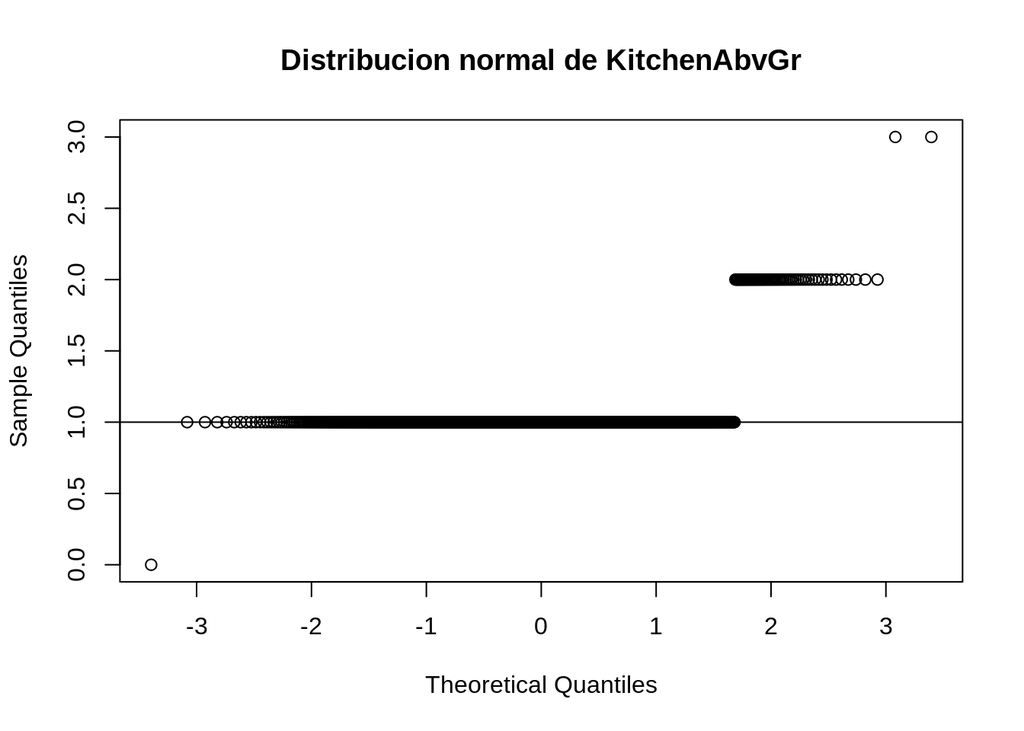

[figure not shown]

[figure not shown]

[figure not shown]

```r
qqnorm(na.omit(as.numeric(dataSet$KitchenAbvGr)),main = "Distribucion normal de KitchenAbvGr")
qqline(na.omit(as.numeric(dataSet$KitchenAbvGr)))
```

# Análisis de variables cualitativas

### Tablas de frecuencia y gráficas de distribución

A continuación, se muestran gráficos de barras para las variables cualitativas, en el caso de que sean muchos posibles valores de la variable se muestran tablas de frecuencia. Esto se hace para conocer un poco el comportamiento de los datos, poder identificar los valores más predominantes en cada variable, así como también poder identificar si hay valores NAs.

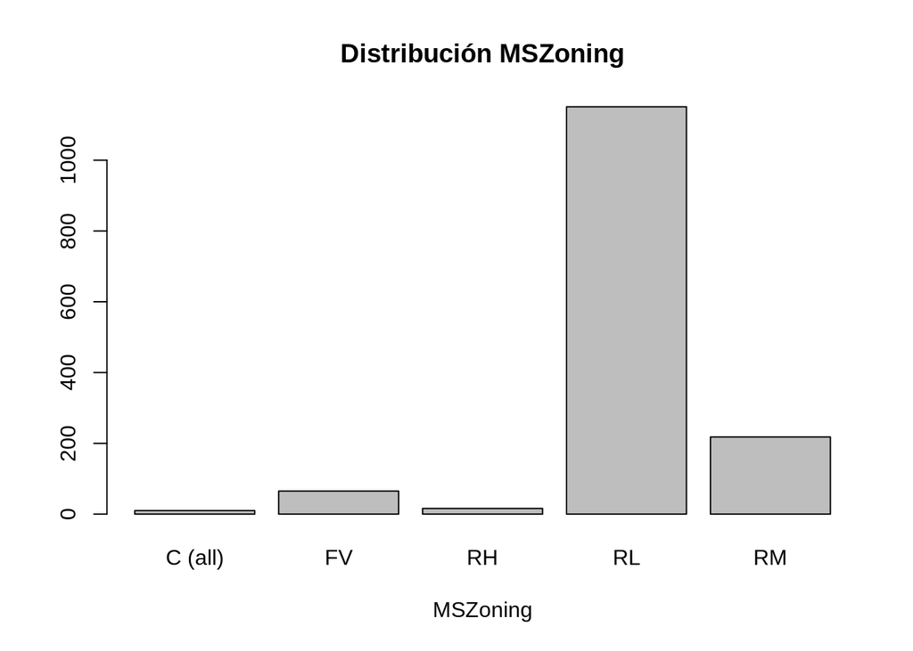

```r
barplot(table(dataSet$MSZoning),main = "Distribución MSZoning",
        xlab="MSZoning")
```

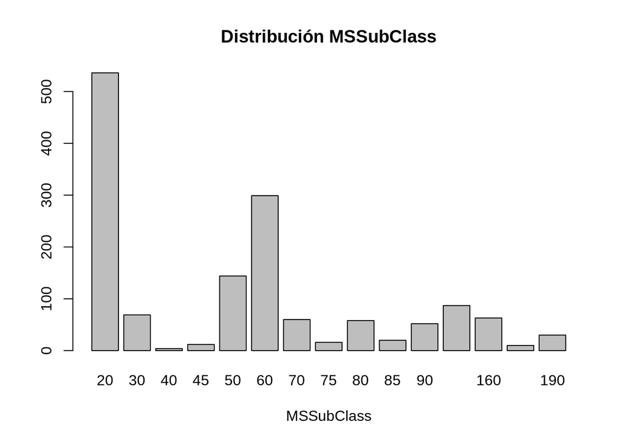

```r
barplot(table(dataSet$MSSubClass),main = "Distribución MSSubClass",
        xlab="MSSubClass")
```

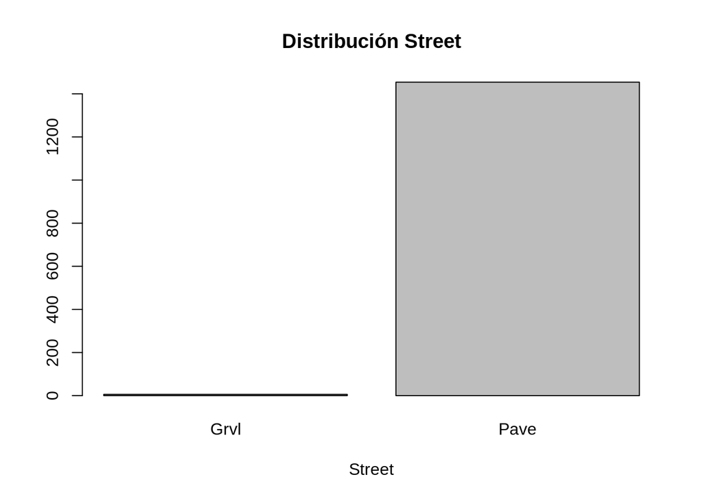

```r
barplot(table(dataSet$Street),main = "Distribución Street",
        xlab="Street")
```

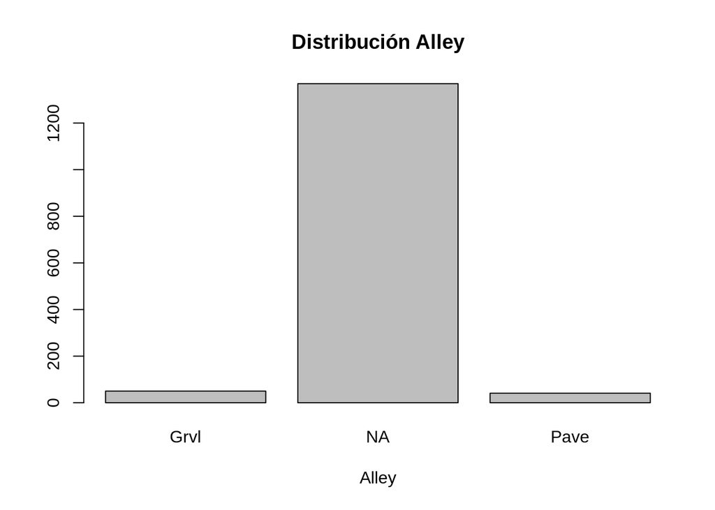

```r
barplot(table(dataSet$Alley),main = "Distribución Alley",
        xlab="Alley")
```

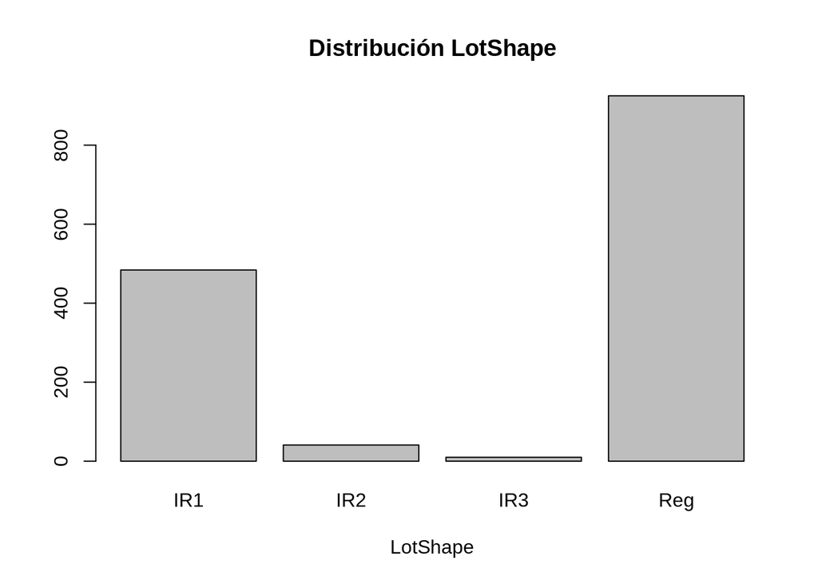

```r
barplot(table(dataSet$LotShape),main = "Distribución LotShape",
        xlab="LotShape")
```

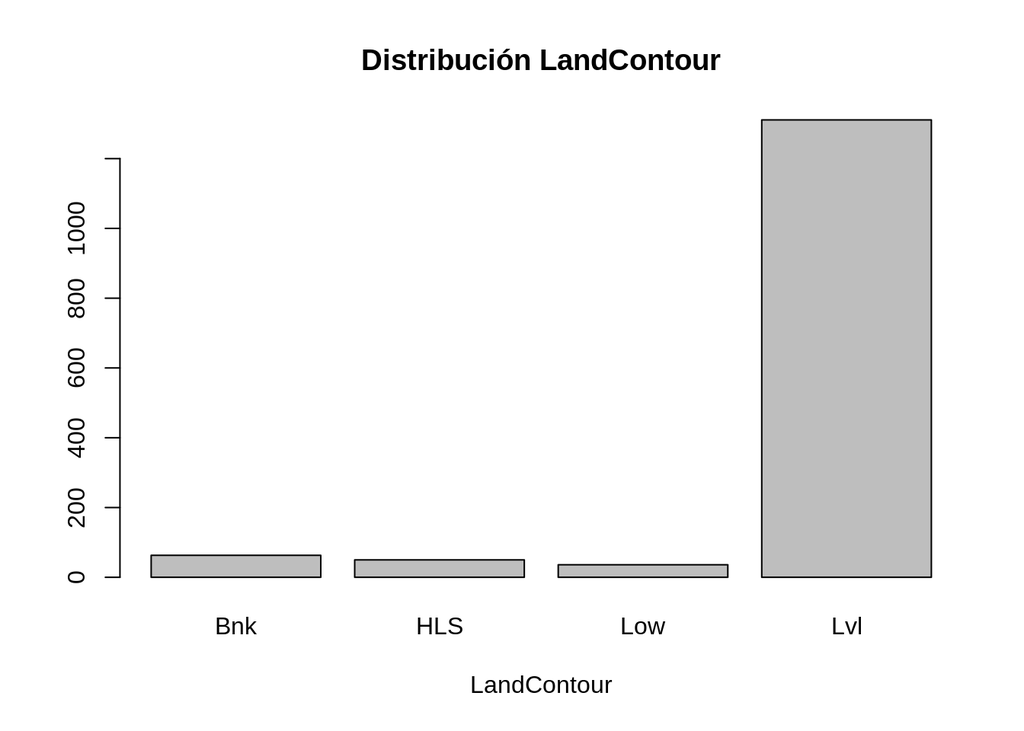

```r
barplot(table(dataSet$LandContour),main = "Distribución LandContour",
        xlab="LandContour")
```

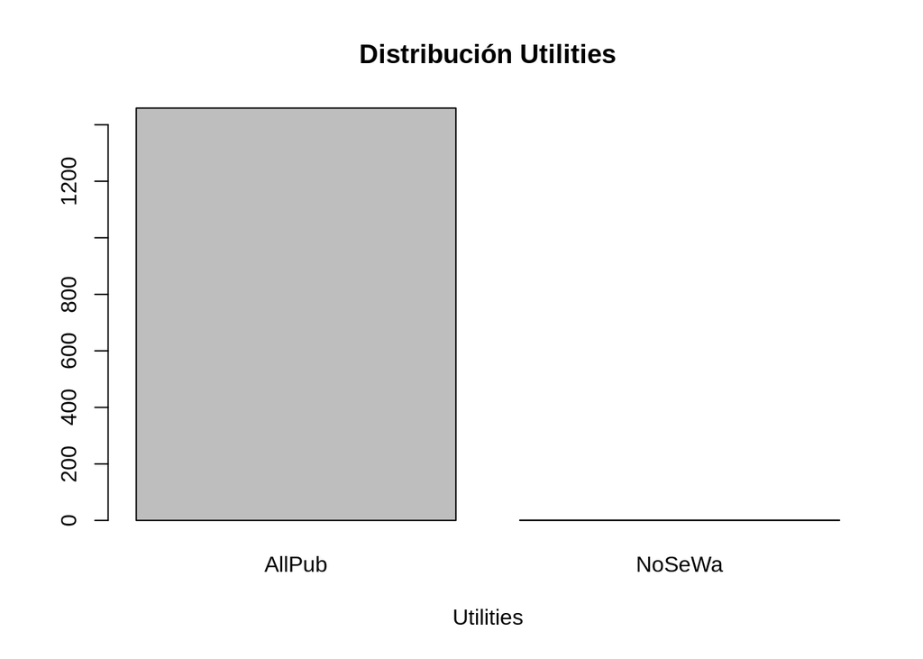

```r
barplot(table(dataSet$Utilities),main = "Distribución Utilities",
        xlab="Utilities")
```

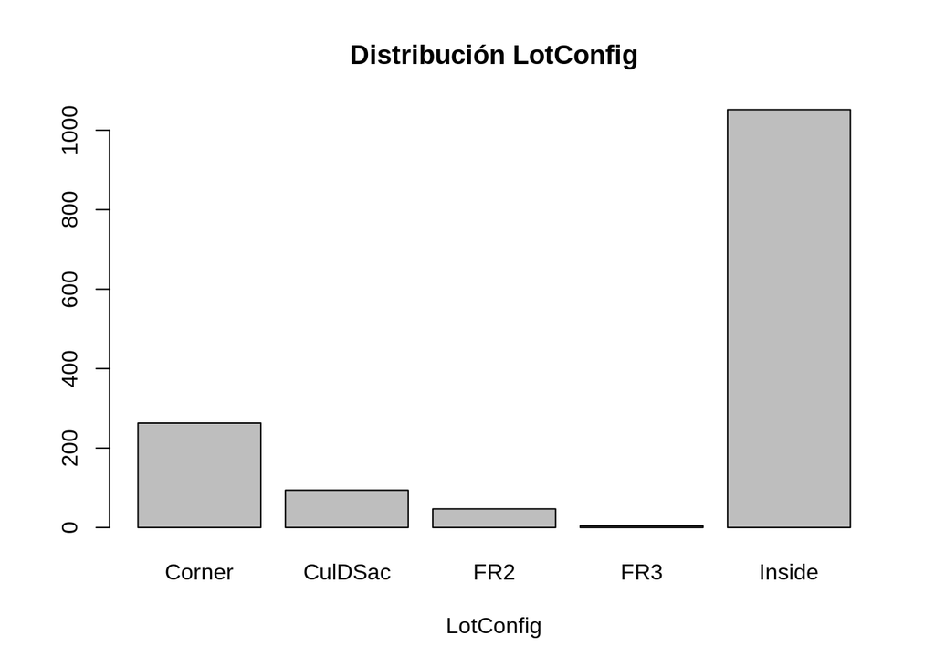

```r
barplot(table(dataSet$LotConfig),main = "Distribución LotConfig",
        xlab="LotConfig")
```

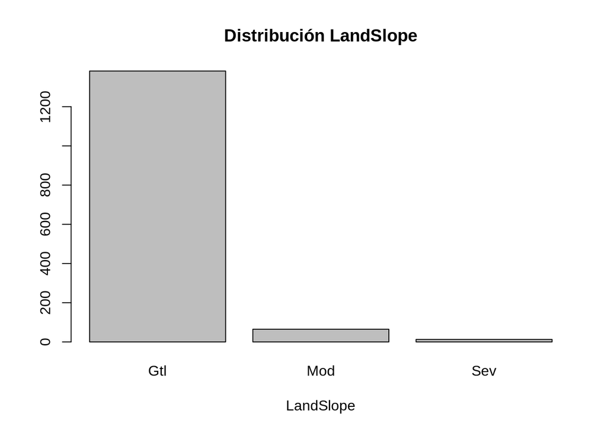

```r
barplot(table(dataSet$LandSlope),main = "Distribución LandSlope",
        xlab="LandSlope")
```

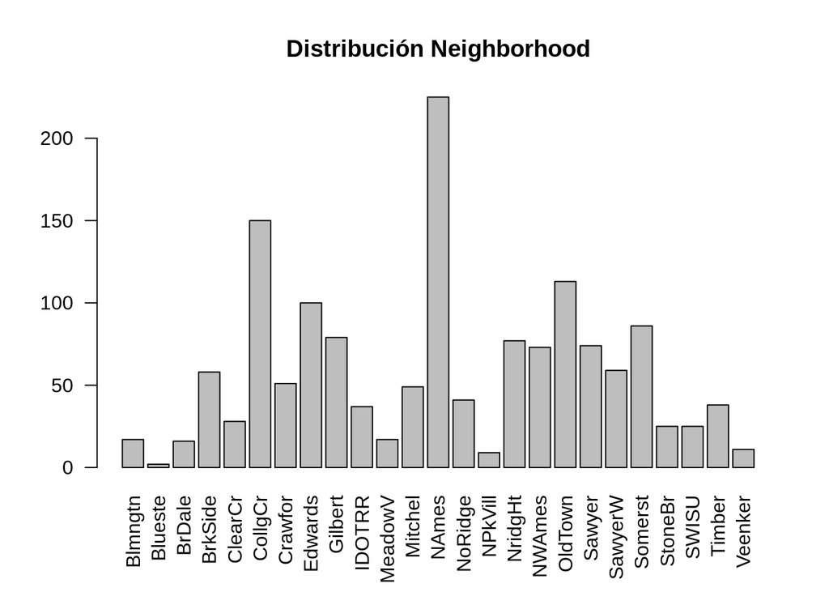

```r
barplot(table(dataSet$Neighborhood),main = "Distribución Neighborhood",las=2)
```

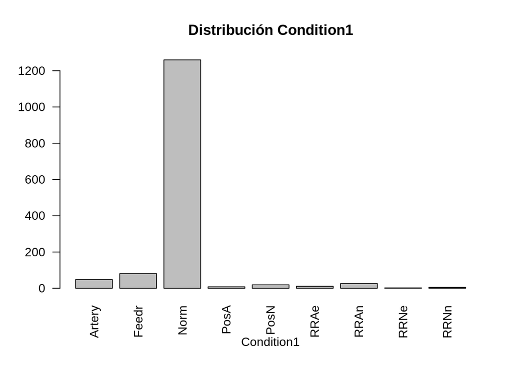

```r
barplot(table(dataSet$Condition1),main = "Distribución Condition1",
        xlab="Condition1",las=2)
```